# RedwineData Exploration by Xin Meng

Sulphates and alcohol go up when quality increases.

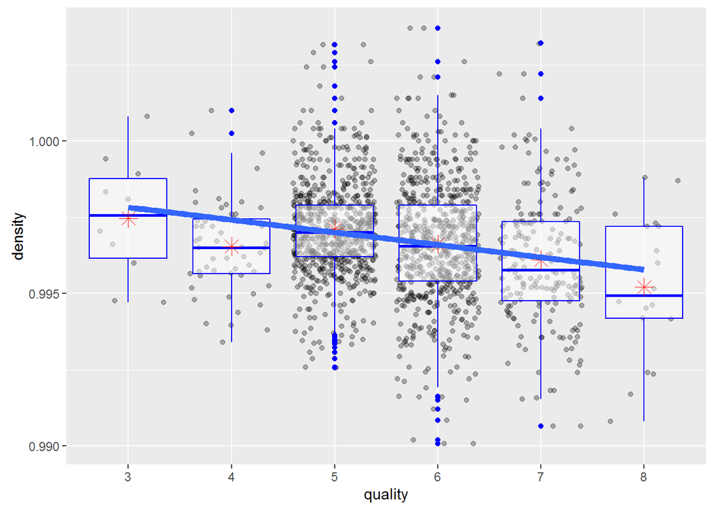

```
##
##  Pearson's product-moment correlation
##
## data:  data$density and data$quality
## t = -7.0997, df = 1597, p-value = 1.875e-12
## alternative hypothesis: true correlation is not equal to 0
## 95 percent confidence interval:
##  -0.2220365 -0.1269870
## sample estimates:
##        cor
## -0.1749192
```

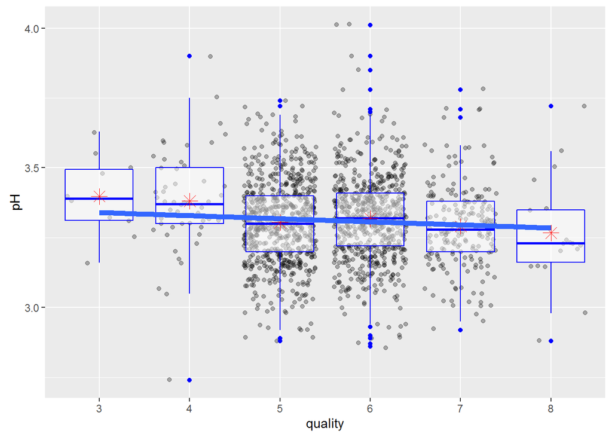

```
##
##  Pearson's product-moment correlation
##
## data:  data$pH and data$quality
## t = -2.3109, df = 1597, p-value = 0.02096
## alternative hypothesis: true correlation is not equal to 0
## 95 percent confidence interval:
##  -0.106451268 -0.008734972
## sample estimates:
##         cor
## -0.05773139
```

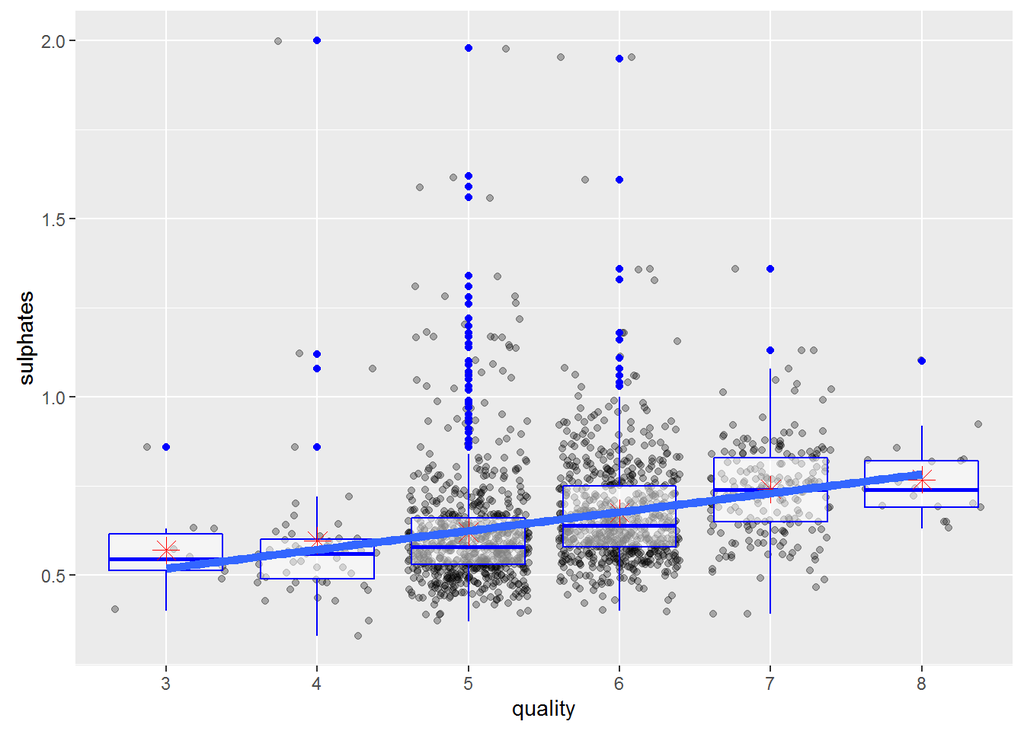

```
##
##  Pearson's product-moment correlation
##
## data:  data$sulphates and data$quality
## t = 10.38, df = 1597, p-value < 2.2e-16
## alternative hypothesis: true correlation is not equal to 0
## 95 percent confidence interval:
##  0.2049011 0.2967610
## sample estimates:
##       cor
## 0.2513971
```

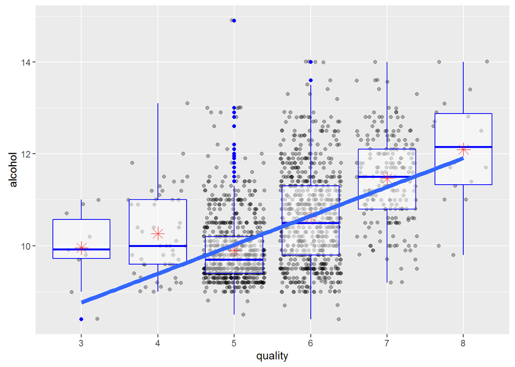

```
##
##  Pearson's product-moment correlation
##
## data:  data$alcohol and data$quality
## t = 21.639, df = 1597, p-value < 2.2e-16
## alternative hypothesis: true correlation is not equal to 0
## 95 percent confidence interval:
##  0.4373540 0.5132081
## sample estimates:
##       cor
## 0.4761663
```

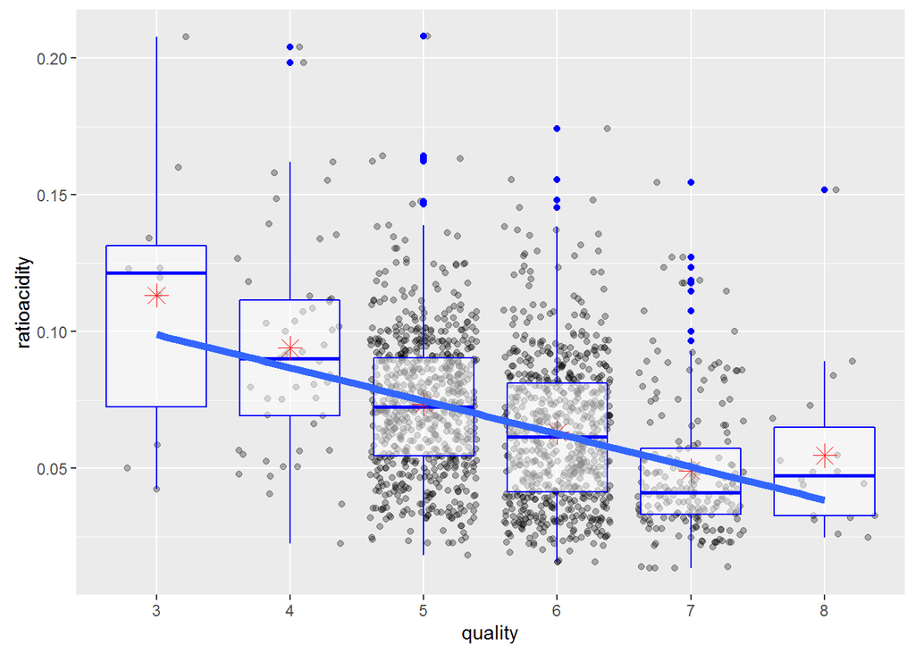

[output not shown]

# Bivariate Analysis

### Talk about some of the relationships you observed in this part of the investigation. How did the feature(s) of interest vary with other features in the dataset?

High quality wine tends to have higher sulphates,citric.acid,alcohol and fixed.acidity, lower pH,volatile.acidity,chlorides,density and ratioacidity.

Total.sulfur.dioxide and Free.sulful.dioxide firstly increase when quality increases, and then go down after reach the highest value when quality is 5. So excellent wine and worse wine both have lower total.sulfur.dioxide and Free.sulful.dioxide, while normal wine has higher total.sulfur.dioxide and Free.sulful.dioxide. Total.sulfur.dioxide and free.sulfur.dioxide are high correlated.

Residual.sugar looks change very slight with quality increases.

### Did you observe any interesting relationships between the other features (not the main feature(s) of interest)?

we found that fixed.acidity and citric.acid ,fixed.acidity and density,free.sulfur.dioxide and total.sulfur.dioxide have high positive correlation.While fixed.acidity and pH, citric.acid and volatile.acidity,citric.acid and pH have high negtive correlation. Ratioacidity and citric.acid has high negtive correlation.

### What was the strongest relationship you found?

Quality may has the strongest relationship with alcohol , volatile.acidity , sulphates and citric.acid.

# Multivariate Plots Section

Let’s do a linear regression with all variables and figure out which have high significant levels pvalue. We lm() with all original variable without selfcreated variable.

```
##  [1] "X"                    "fixed.acidity"        "volatile.acidity"
##  [4] "citric.acid"          "residual.sugar"       "chlorides"
##  [7] "free.sulfur.dioxide"  "total.sulfur.dioxide" "density"
## [10] "pH"                   "sulphates"            "alcohol"
## [13] "quality"              "ratioacidity"
```

```
##
## Call:
## lm(formula = quality ~ ., data = data[, -c(1, 14)])
##
## Residuals:
##      Min       1Q   Median       3Q      Max
## -2.68911 -0.36652 -0.04699  0.45202  2.02498
##
## Coefficients:
##                        Estimate Std. Error t value Pr(>|t|)
## (Intercept)           2.197e+01  2.119e+01   1.036   0.3002
## fixed.acidity         2.499e-02  2.595e-02   0.963   0.3357
## volatile.acidity     -1.084e+00  1.211e-01  -8.948  < 2e-16 ***
## citric.acid          -1.826e-01  1.472e-01  -1.240   0.2150
## residual.sugar        1.633e-02  1.500e-02   1.089   0.2765
## chlorides            -1.874e+00  4.193e-01  -4.470 8.37e-06 ***
## free.sulfur.dioxide   4.361e-03  2.171e-03   2.009   0.0447 *
## total.sulfur.dioxide -3.265e-03  7.287e-04  -4.480 8.00e-06 ***
## density              -1.788e+01  2.163e+01  -0.827   0.4086
## pH                   -4.137e-01  1.916e-01  -2.159   0.0310 *
## sulphates             9.163e-01  1.143e-01   8.014 2.13e-15 ***
## alcohol               2.762e-01  2.648e-02  10.429  < 2e-16 ***
## ---
## Signif. codes:  0 '***' 0.001 '**' 0.01 '*' 0.05 '.' 0.1 ' ' 1
##
## Residual standard error: 0.648 on 1587 degrees of freedom
## Multiple R-squared:  0.3606, Adjusted R-squared:  0.3561
## F-statistic: 81.35 on 11 and 1587 DF,  p-value: < 2.2e-16
```

We got volatile.acidity,chlorides,total.sulfur.dioxide,sulphates,alcohol have high significant pvalue.The R^2 = 0.3561.We keep these variables and do log10 transformation on total.sulfur.dioxide and alcohol,because they are right skewed. We do linear regression again.This time we got R^2=0.3462 which is pretty low.That means only 0.3462 of y variance be explained by the model. Let see the residuals plot. We can see a clearly pattern on the plot , that means there’s some informations the model not captured, the model is poor.We also see the maximun residual is >2.0 ,so the model can mistake the predict quality to far beyond the neighbor quality.

```
##
## Call:
## lm(formula = quality ~ volatile.acidity + chlorides + log10(total.sulfur.dioxide) +
##     sulphates + log10(alcohol), data = data[, -c(1)])
##
## Residuals:
##      Min       1Q   Median       3Q      Max
## -2.66342 -0.37368 -0.06118  0.45843  2.09191
##
## Coefficients:
##                             Estimate Std. Error t value Pr(>|t|)
## (Intercept)                 -0.96388    0.45968  -2.097 0.036164 *
## volatile.acidity            -1.15114    0.09716 -11.848  < 2e-16 ***
## chlorides                   -1.65765    0.39337  -4.214 2.65e-05 ***
## log10(total.sulfur.dioxide) -0.18736    0.05528  -3.390 0.000717 ***
## sulphates                    0.91021    0.11093   8.206 4.68e-16 ***
## log10(alcohol)               6.93666    0.41398  16.756  < 2e-16 ***
## ---
## Signif. codes:  0 '***' 0.001 '**' 0.01 '*' 0.05 '.' 0.1 ' ' 1
##
## Residual standard error: 0.653 on 1593 degrees of freedom
## Multiple R-squared:  0.3482, Adjusted R-squared:  0.3462
## F-statistic: 170.2 on 5 and 1593 DF,  p-value: < 2.2e-16
```

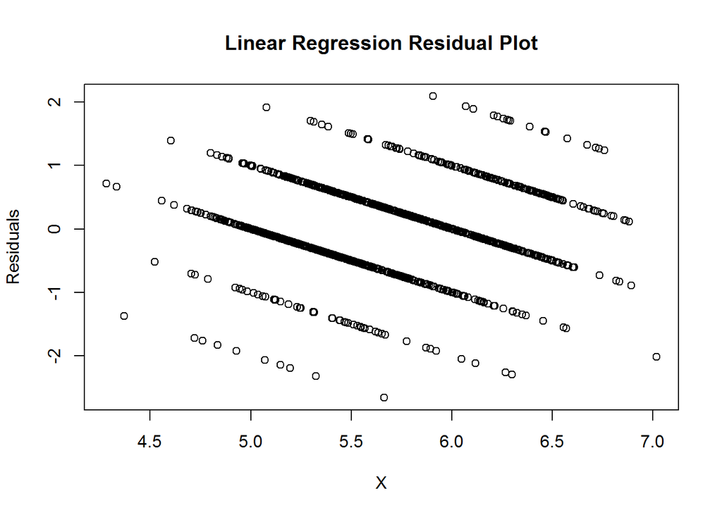

```
##     Min.  1st Qu.   Median     Mean  3rd Qu.     Max.
## -2.66300 -0.37370 -0.06118  0.00000  0.45840  2.09200
```

We found that these variables are almost 5 totally different things. Volatile.acidity is about acetic acid, chlorides is about salt, alcohol is alcohol.Only total.sulfur.dioxide and sulphates might have slight relationship, they are both about sulfur.Let’s examine the two variables. This plot show sulphates and total.sulfur.dioxide with data In the plot of sulphates and total.sulfur.dioxide. The linear correlation coefficient changes when quality increases. The coef from positive changes from positive to negtive when quality increases. So linear regression model is insufficient to decribe the pattern of the dataset. It must search for more complex model,such as SVM.

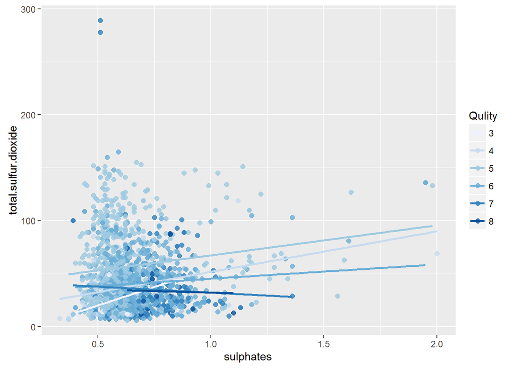

We examin the correlation of alcohol and volatile.acidity We also see the pattern of correlation coefficient changes with quality.

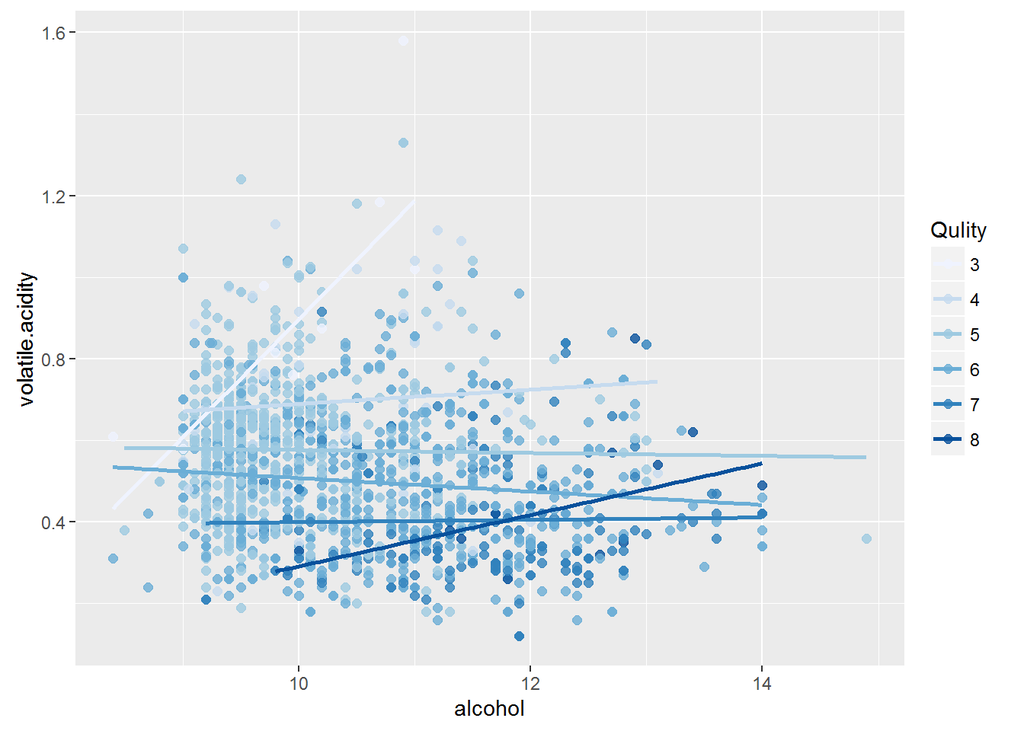

The correlation coefficient of alcohol and chlorides changes with quality.

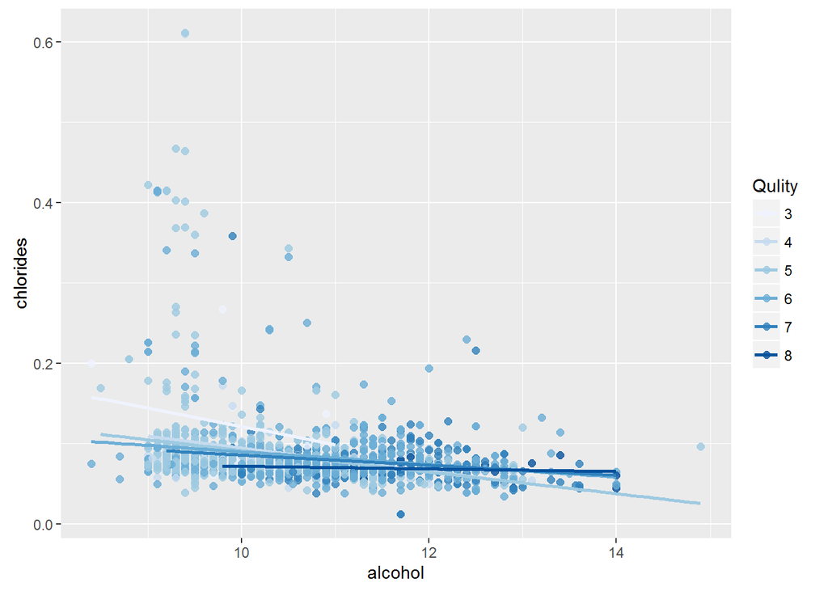

We also find that the r^2 is only 0.35 even with all 5 variables have significant pvalue. We also see the correlation coef of variables changes with quality.So linear regression model is insufficient to explain the variance of quality. We may pursue more complex model. Correlation Coefficients only show they have weak linear correlation, but they may have non linear relationship.

I tried multinominal log-linear regression. I got AIC=3051 with all variables except X(sample sequence number) and selfimplement varialbe “radioacidiy”.From the residuals summary, we can see in each predict quality, 1st Qu.is greater than -0.5 and 3rd Qu.is less than 0.5. So more than 50% predict values can be round to correct quality scores. Most residuals occur in quality = 5,6,7. That because most samples have quality 5,6,7. The maximum residual is nearly 1.0 or -1.0, which is pretty smaller than residuals in linear regression model.And that means it predict might mistake quality to the neighbor quality score.I think this mistaken is quite reasonable and acceptable. I think multinominal log-linear model do better prediction than linear regression model in this dataset.

```
##  [1] "X"                    "fixed.acidity"        "volatile.acidity"
##  [4] "citric.acid"          "residual.sugar"       "chlorides"
##  [7] "free.sulfur.dioxide"  "total.sulfur.dioxide" "density"
## [10] "pH"                   "sulphates"            "alcohol"
## [13] "quality"              "ratioacidity"
```

```
## Call:
## multinom(formula = factor(quality) ~ ., data = data[, -c(1, 14)])
##
## Coefficients:
##   (Intercept) fixed.acidity volatile.acidity citric.acid residual.sugar
## 4   21.720879    -0.8652496        -4.618994  -1.8418384     0.11907530
## 5    8.086435    -0.8958076        -7.650297  -2.5019255    -0.08671914
## 6    7.646962    -0.7982383       -10.308983  -3.7834668    -0.05057762
## 7   27.446367    -0.7327195       -12.706308  -3.2791550     0.10212724
## 8   19.514590    -1.2400509        -8.692210  -0.2977042    -0.05598066
##   chlorides free.sulfur.dioxide total.sulfur.dioxide   density         pH
## 4 -13.18214          -0.1709746           0.08720849  4.325176  -9.064021
## 5 -15.00312          -0.1497630           0.10366284 33.361133 -11.517406
## 6 -17.73087          -0.1281721           0.08721680 25.958333 -11.687264
## 7 -25.99006          -0.1232488           0.07598264 -1.950556 -12.198667
## 8 -48.55761          -0.1149803           0.05853680 18.775445 -18.329190
##   sulphates  alcohol
## 4  1.742318 1.677260
## 5  1.778081 1.414021
## 6  4.110681 2.229843
## 7  6.719634 2.921011
## 8  8.488034 3.582408
##
## Std. Errors:
##   (Intercept) fixed.acidity volatile.acidity citric.acid residual.sugar
## 4   2.1004108     0.2904219         1.590284    1.443412      0.2062750
## 5   1.2039680     0.2631205         1.513593    1.099202      0.1901962
## 6   1.1366644     0.2627592         1.529667    1.074754      0.1917086
## 7   1.5727016     0.2682882         1.658475    1.176819      0.1987653
## 8   0.5304287     0.3148883         2.411912    2.092169      0.3176994
##   chlorides free.sulfur.dioxide total.sulfur.dioxide   density       pH
## 4 2.9146231          0.08402920           0.04784786 2.0511427 1.945990
## 5 1.5692584          0.08099145           0.04731409 1.1789707 1.681602
## 6 1.5505007          0.08099066           0.04732275 1.1155790 1.677782
## 7 2.8080590          0.08178299           0.04756522 1.5362529 1.769075
## 8 0.1247103          0.08969719           0.04989980 0.5263315 1.890889
##   sulphates   alcohol
## 4 1.2894936 0.7090651
## 5 0.8401622 0.6909789
## 6 0.8138552 0.6921375
## 7 0.8710810 0.6972217
## 8 1.3491068 0.7447235
##
## Residual Deviance: 2931.106
## AIC: 3051.106
```

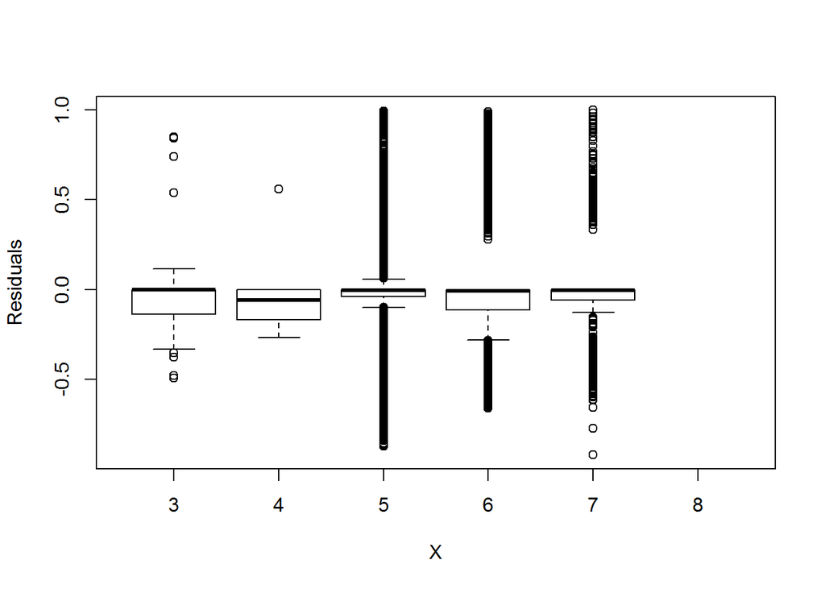

```
##        3                    4                    5
##  Min.   :-0.4928889   Min.   :-0.3531329   Min.   :-0.8729844
##  1st Qu.:-0.0013690   1st Qu.:-0.0381910   1st Qu.:-0.3211350
##  Median :-0.0001927   Median :-0.0176516   Median :-0.0511389
##  Mean   :-0.0000217   Mean   :-0.0000577   Mean   : 0.0001832
##  3rd Qu.:-0.0000137   3rd Qu.:-0.0074929   3rd Qu.: 0.3356550
##  Max.   : 0.9934791   Max.   : 0.9952520   Max.   : 0.9996762
##        6                    7                    8
##  Min.   :-0.6633823   Min.   :-0.9229273   Min.   :-0.3601998
##  1st Qu.:-0.3997714   1st Qu.:-0.1002281   1st Qu.:-0.0060581
##  Median :-0.1810425   Median :-0.0235089   Median :-0.0008430
##  Mean   : 0.0001687   Mean   :-0.0001726   Mean   :-0.0000999
##  3rd Qu.: 0.4644527   3rd Qu.:-0.0047167   3rd Qu.:-0.0001124
##  Max.   : 0.9237894   Max.   : 0.9942934   Max.   : 0.9819244
```

# Multivariate Analysis

### Talk about some of the relationships you observed in this part of the investigation. Were there features that strengthened each other in terms of looking at your feature(s) of interest?

In our linear regression model:volatile.acidity+chlorides+total.sulfur.dioxide+sulphates+alcohol are have significant pvalus.

Volatile.acidity decreases when quality increase. High quality wine has lower volatile.acidity.

Chlorides go down when quality increases.High quality wine has less salt.

Sulphates and alcohol go up when quality increases.High quality wine has more alcohol and sulphates,which is acted as antioxidant.

Total.sulfur.dioxide is not monotonous,it goes up when quality goes from bad to normal and goes down when quality goes from normal to excellent.So it is mysterious how it act in quality.

### Were there any interesting or surprising interactions between features?

Total.sulfur.dioxide is not monotonous,it goes up when quality goes from bad to normal and goes down when quality goes from normal to excellent.So it is mysterious how it act in quality.

### OPTIONAL: Did you create any models with your dataset? Discuss the strengths and limitations of your model.

Firstly,I created a linear regression model removing X and ratioacidity variables with lm(quality~volatile.acidity+chlorides+total.sulfur.dioxide+sulphates+alcohol,data=data[, -c(1,14)])

I only got r^2 is 0.35, which is pretty low. It implies that linear regression model can’t explain the variance of quality. Correlation Coefficients only show they have weak linear correlation, but they may have non linear correlation. Pair of variables’s correlation coefficient changes when quality changes. That’s also indicate that linear regression is not sufficient for modelling in the dataset. We must pursue more complex model. I have read the abstract of the article ’Modeling wine preferences by data mining from physicochemical properties.’by P. Cortez, A. Cerdeira, F. Almeida, T. Matos and J. Reis.(http://www.sciencedirect.com/science/article/pii/S0167923609001377).They used SVM to create the model.

I also tried multinominal logistic model has AIC =3051.

mul_red<-multinom(quality~.,data=data[, -c(1,14)])

I used residuals plot to compare multinominal log-linear model and linear regression model.And multinominal log-linear model is better for this dataset.

# Final Plots and Summary

### Plot One

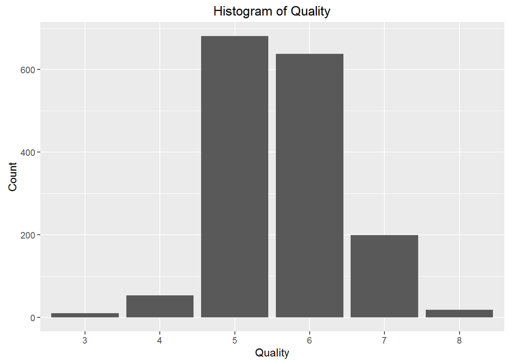

```
##    Min. 1st Qu.  Median    Mean 3rd Qu.    Max.
##   3.000   5.000   6.000   5.636   6.000   8.000
```

### Description One

Most samples quality scores are 5,6 and 7,fewer samples are less than 5 or more than 7.The quality scores were graded by expert between 0(very bad) and 10(very excellent).That means there are much more normal wines than excellent or poor ones.The distribution is nearly Normal distribution.

### Plot Two

```
##                         estimate
## fixed.acidity          0.1240516
## volatile.acidity      -0.3905578
## citric.acid            0.2263725
## residual.sugar        0.01373164
## chlorides             -0.1289066
## free.sulfur.dioxide  -0.05065606
## total.sulfur.dioxide  -0.1851003
## density               -0.1749192
## pH                   -0.05773139
## sulphates              0.2513971
## alcohol                0.4761663
```

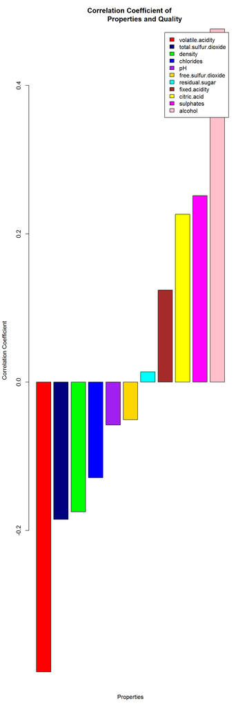

### Description Two

In this plot we see there’s no variable have strong linear relationship with quality. The highest correlaton coefficient is alcohol of 0.47, which is a moderate correlation. Correlation coefficient only measures linear relationship.They are may be some nonlinear relationship with quality and some variables.They can’t be identified by linear regression model.So a better model of the redwine dataset might be more complex than linear regression model.

### Plot Three

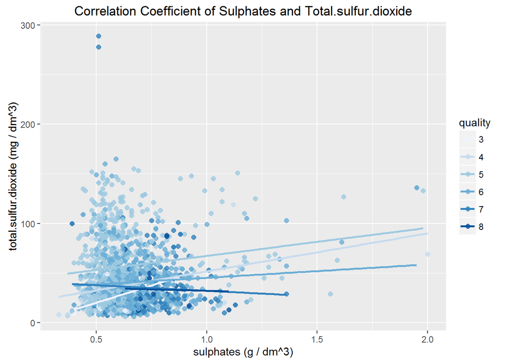

### Description Three

In the plot of sulphates and total.sulfur.dioxide. The linear correlation coefficient changes when quality increases. The coef from positive changes from positive to negtive when quality increases. So linear regression model is insufficient to decribe the pattern of the dataset. It must search for more complex model,such as SVM.

# Reflection

The redwine data set contains information on 1599 samples of red wine across 12 features( “fixed.acidity”,“volatile.acidity”,“citric.acid”,“residual.sugar”,“chlorides”,“free.sulfur.dioxide”,“total.sulfur.dioxide”,“density”,“pH”,“sulphates”,“alcohol”,“quality”). The project is explore analysis on the relationship of physicochemical properties and quality scores.I started by understanding the individual variables in the data set, and then I explored the relationship with each variable and quality. I explored correlation coefficient of each two variables and quality.I found some interesting nonmonotonous patterns of total.sulfur.dioxide and free.sulfur.dioxide with quality. I also found correlation coefficients of each property variable changes with quality. Eventually, I used linear regression model and got R^2 only 0.35 and compared with a multinominal log-linear model with residual plot to found out multinominal log-linear model is better(lower residual) than linear regression to predict the quality.

I have discussed the weakness of correlation coefficent on variables and quality, and the correlation coefficent changes with quality. So linear regression model is not enough to capture the pattern of dataset. It must search for more complex model,such as SVM.

I think further analysis can study on multinominal or SVM to built a model to explain the variance of quality and predict quality with physicalchemical properties.